# Genomics QC Report

Author

GDC Data Team

Published

October 19, 2023

# General Summary

[output not shown]

## Data Processing

[figure not shown]

# Detailed QC summary

## Per Subject summary

Subjects were filtered based on missingness and heterozygosity. An LD pruning step was also performed.

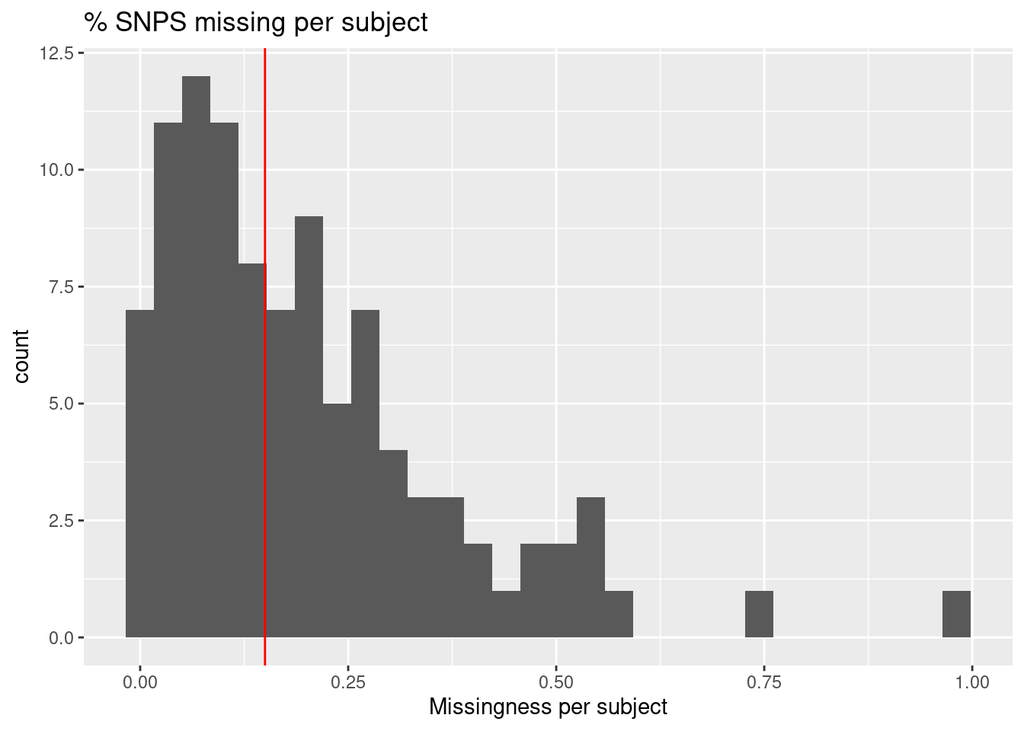

The [heterozygosity F statistic (FIS)](https://en.wikipedia.org/wiki/F-statistics) the departure from HWE in a population. The heterozygosity F statistic is given by the following equation:
$$F = \frac{1}{N}\sum_{i=1}^N \frac{O_i - E_i}{E_i}$$

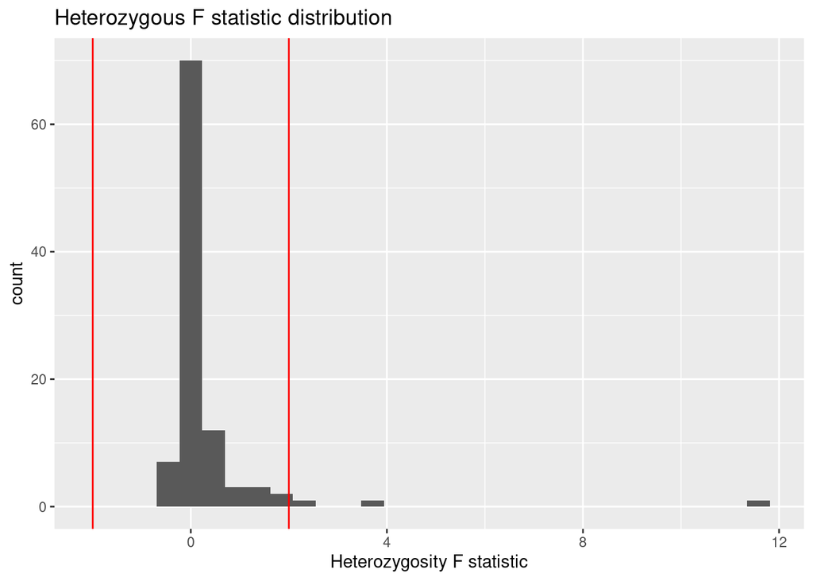

Figure 1: Heterozygosity distributions with cutoff shown as red vertical line.

## Per SNP summary

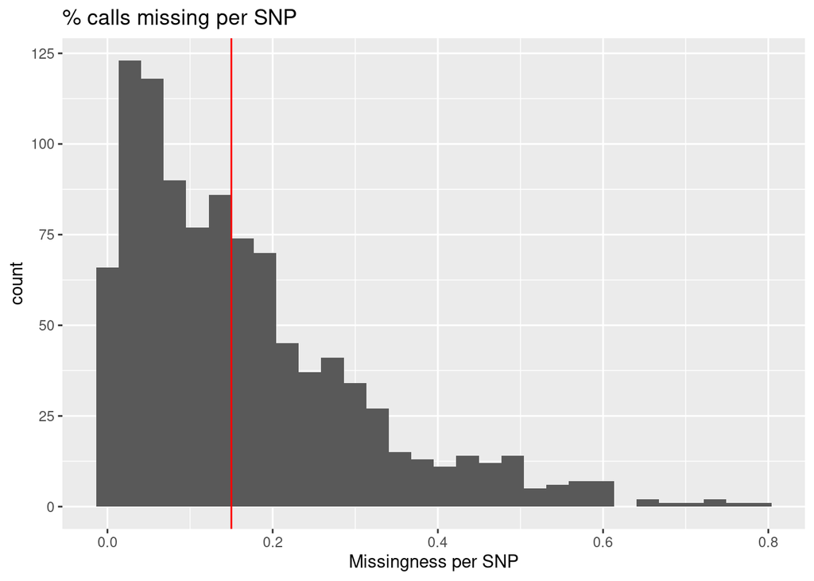

Figure 2: Missingness, MAF, and HWE filters involved in initial SNP filtering. Cutoffs are shown as red vertical lines

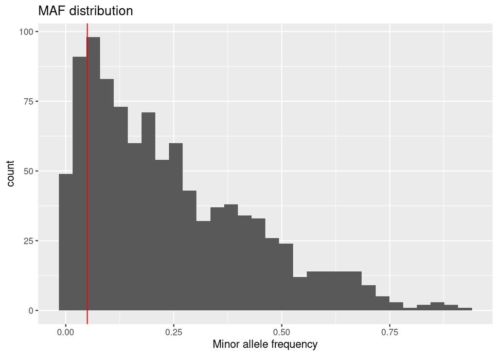

Figure 3: Missingness, MAF, and HWE filters involved in initial SNP filtering. Cutoffs are shown as red vertical lines

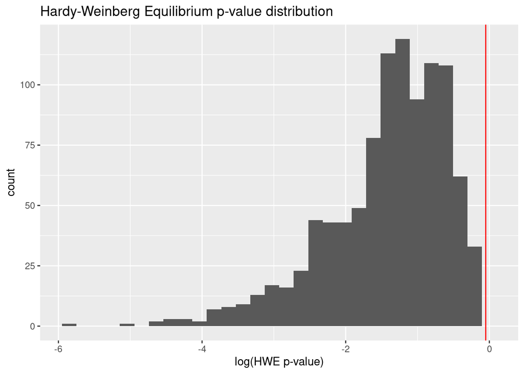

Figure 4: Missingness, MAF, and HWE filters involved in initial SNP filtering. Cutoffs are shown as red vertical lines

## Ancestry predictions

Ancestries are predicted after the initial round of QC steps. The principal components upon which the population is stratifed, are based off of the [genetic relatedness matrix (GRM)](https://zjuwhw.github.io/2021/08/20/GRM.html). The subjects are then projected onto the PC space and assigned ethnicities using k-means clustering based on either a standard genomic dataset (such as though genomes) are by the reported ancestries of the subject in the study. Figure Figure 5) the projection of each subject onto the first few PCs. They are colored by their reported ancestries.

The densities of ancestries based on the reference set are represent by the 10% contour lines of the 2d density plots with the observed populations presented as points over top of the densities shown in Figure 5.

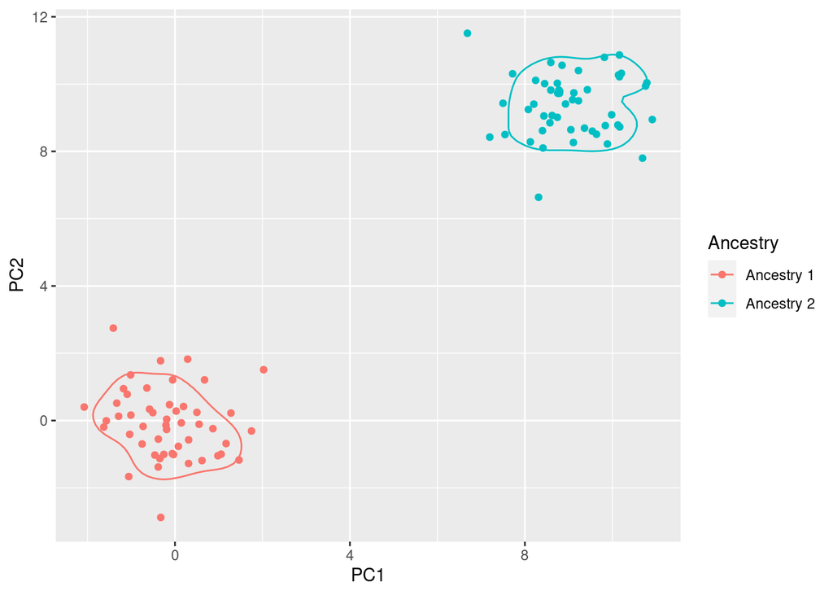

Figure 5: Ancestry predictions plotted over first decile contour for each ancestry.

## Per Ancestry summary

We also summarize the QC metrics per ancestry. Figure 6) shows the distribution of MAF per ancestry.

[figure not shown]

Figure 6: MAF faceted by ancestry with the cutoff vizualized as a red vertical line.

# GWAS

Results of Genome Wide Association Study (GWAS) are visualized in Figure 7.

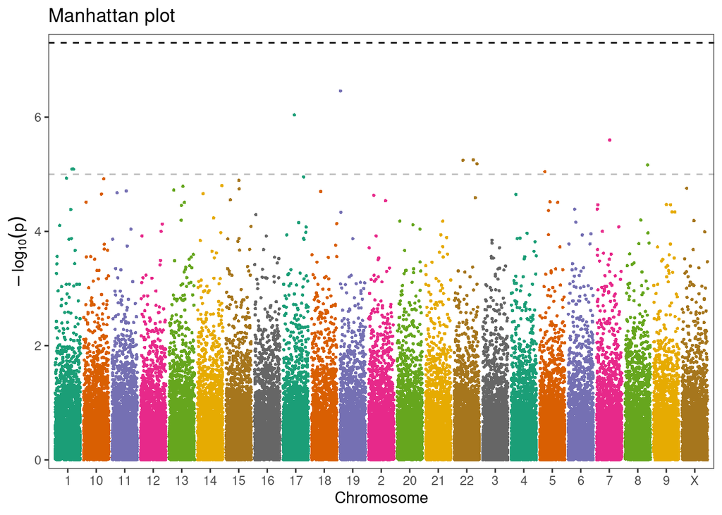

Figure 7: log pvalue of GWAS colored by chromosome.

# Additional information

## Contact

Saonli Basu, PhD (saonli@umn.edu) Director of Analytics MIDB